# Caso Práctico 06: BMW vs Volkswagen

Hugo César Octavio del Sueldo

11/25/2020

## Introducción

[figure not shown]

Utilizando datos diarios de las dos series desde el año 2014, debemos analizar la relación entre BMW y Volkswagen, contestando a las siguiente preguntas:

- ¿Estimar el modelo garch de BMW?
- ¿Están cointegradas?
- Plantear un modelo VAR mensual entre los dos activos.
- Estimar un modelo HHM para la serie semanal de BMW

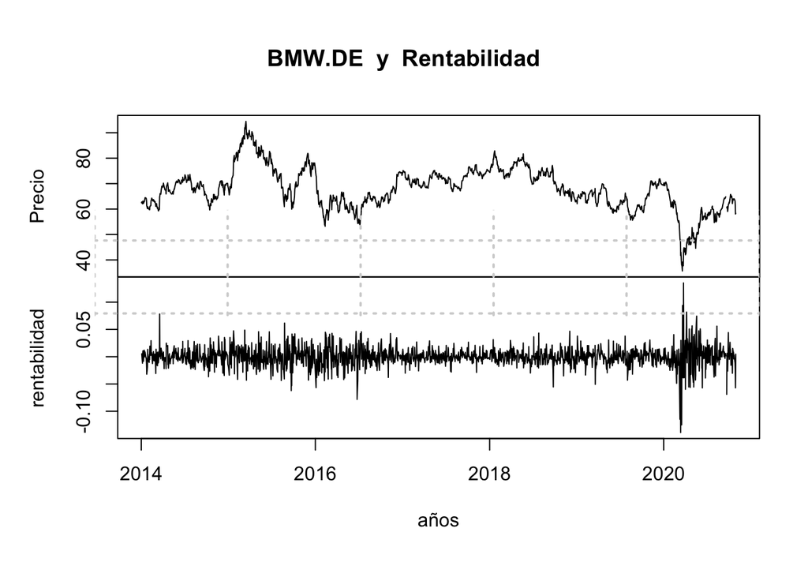

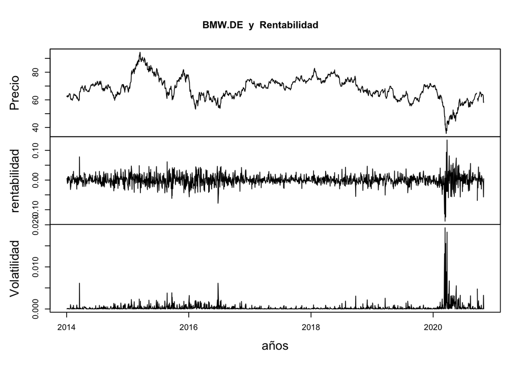

```
##
##  One Sample t-test
##
## data:  dRentCont
## t = -0.093641, df = 1727, p-value = 0.9254
## alternative hypothesis: true mean is not equal to 0
## 95 percent confidence interval:
##  -0.0008713763  0.0007919625
## sample estimates:
##     mean of x
## -3.970692e-05
```

Vamos a analizar los graficos de ACF y PACF

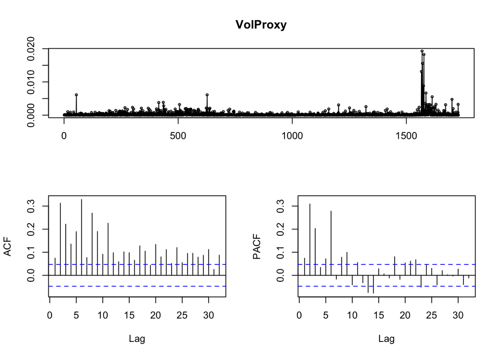

Observamos que la volatilidad no es ruido blanco. A continuacion comprobaremos con un archTest la hipotesis de que el modelo es GARCH o no lo es.

```r
#LM test
archTest(dRentCont,20)
```

[output not shown]

Para continuar con nuestro modelo GARCH, primero vamos a averiguar cual es el orden del modelo ARMA para utilizar y agregar este orden en nuestro modelo GARCH

```r
(fit_BMW <- auto.arima(dRentCont, seasonal = TRUE))
```

```
## Series: dRentCont
## ARIMA(3,0,1) with zero mean
##
## Coefficients:
##           ar1     ar2     ar3     ma1
##       -0.7436  0.0684  0.1077  0.7726
## s.e.   0.0649  0.0299  0.0244  0.0613
##
## sigma^2 estimated as 0.0003067:  log likelihood=4539.5
## AIC=-9068.99   AICc=-9068.96   BIC=-9041.72
```

Vamos a utilizar un modelo ARMA(3,1) + GARCH(1,2) para nuestro modelo.

```
##
## Title:
##  GARCH Modelling
##
## Call:
##  garchFit(formula = ~1 + arma(3, 1) + garch(1, 2), data = dRentCont,
##     trace = F)
##
## Mean and Variance Equation:
##  data ~ 1 + arma(3, 1) + garch(1, 2)
## <environment: 0x7fe5f45032c8>
##  [data = dRentCont]
##
## Conditional Distribution:
##  norm
##
## Coefficient(s):
##          mu          ar1          ar2          ar3          ma1        omega
##  3.4899e-04  -3.1180e-01   5.8744e-02   5.6019e-02   3.8579e-01   3.5470e-06
##      alpha1        beta1        beta2
##  7.7255e-02   2.9623e-01   6.1618e-01
##
## Std. Errors:
##  based on Hessian
##
## Error Analysis:
##          Estimate  Std. Error  t value Pr(>|t|)
## mu      3.490e-04   4.664e-04    0.748   0.4543
## ar1    -3.118e-01   2.489e-01   -1.253   0.2103
## ar2     5.874e-02   3.213e-02    1.828   0.0675 .
## ar3     5.602e-02   2.617e-02    2.140   0.0323 *
## ma1     3.858e-01   2.482e-01    1.554   0.1201
## omega   3.547e-06   1.417e-06    2.502   0.0123 *
## alpha1  7.725e-02   1.294e-02    5.971 2.36e-09 ***
## beta1   2.962e-01   1.526e-01    1.941   0.0522 .
## beta2   6.162e-01   1.473e-01    4.184 2.87e-05 ***
## ---
## Signif. codes:  0 '***' 0.001 '**' 0.01 '*' 0.05 '.' 0.1 ' ' 1
##
## Log Likelihood:
##  4758.776    normalized:  2.753921
##
## Description:
##  Sat Nov 28 11:51:09 2020 by user:
##
##
## Standardised Residuals Tests:
##                                 Statistic p-Value
##  Jarque-Bera Test   R    Chi^2  740.8523  0
##  Shapiro-Wilk Test  R    W      0.9724078 0
##  Ljung-Box Test     R    Q(10)  6.574246  0.764934
##  Ljung-Box Test     R    Q(15)  10.9694   0.7547608
##  Ljung-Box Test     R    Q(20)  17.20376  0.6397057
##  Ljung-Box Test     R^2  Q(10)  18.20506  0.05160152
##  Ljung-Box Test     R^2  Q(15)  19.75121  0.1816858
##  Ljung-Box Test     R^2  Q(20)  23.50506  0.2646804
##  LM Arch Test       R    TR^2   18.83925  0.09248246
##
## Information Criterion Statistics:
##       AIC       BIC       SIC      HQIC
## -5.497426 -5.469016 -5.497480 -5.486917
```

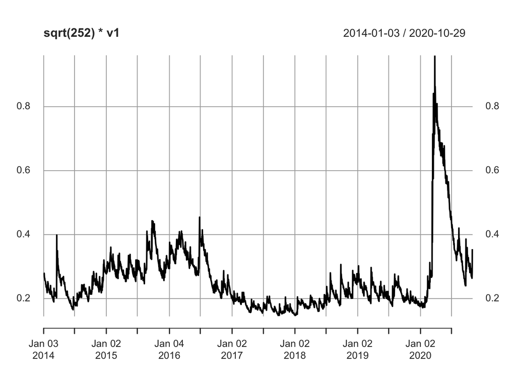

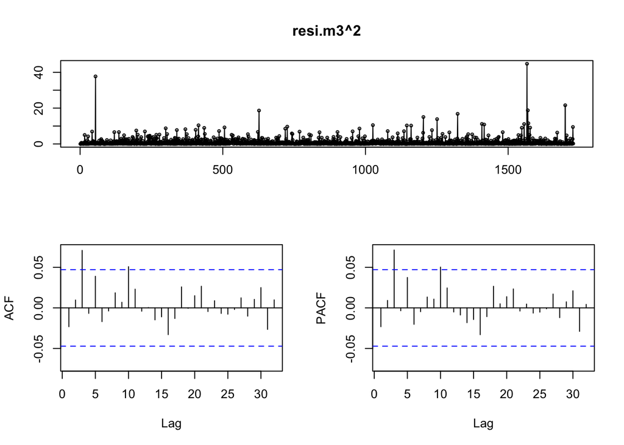

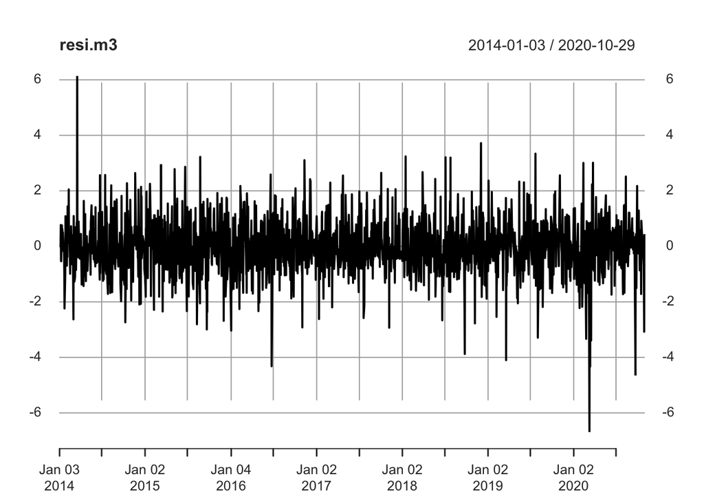

Observamos aqui por los test de box-Ljung que para diferentes periodos el modelo tiene varianza ruido blanco por el valor del p value. Esto mismo lo confirmamos en el grafico de los residuales al cuadrado.

## Prediccion

```r
#Estuve tratando de hacer la prediccion de mi modelo pero no pude lograrlo porque el paquete tiene un error.

#Error in a_vec[(i - 1):(i - u2)] :
#  only 0's may be mixed with negative subscripts

predict(m3) #forecast volatility

predict(m3, n.ahead = 10, plot=TRUE, crit_val=2) #plot with 2*standard error
predict(m3,n.ahead=20,plot=TRUE,conf=.9,nx=100) # plot 100 data with 90% confidence
```

## - Plantear un modelo VAR mensual entre los dos activos.

Calculamos la primera diferencia para hacerlas estacionarias

```r
BMW.DE.ret <- diff(log(Ad(BMW.DE)))
VOW.DE.ret <- diff(log(Ad(VOW.DE)))
```

```r
#generar vector

vY=cbind(BMW.DE.ret,VOW.DE.ret) #vector con los dos rendimientos
colnames(vY)=c("BMW","VOW") #le ponemos nombres
vY=na.omit(vY) #omitimos los na

#Seleccionar modelo

VARselect(vY) #selecciona el orden 1 para los 4 tipos de indicadores de seleccion de modelos VAR
```

```
## $selection
## AIC(n)  HQ(n)  SC(n) FPE(n)
##      1      1      1      1
##
## $criteria
##                    1             2             3             4             5
## AIC(n) -1.715605e+01 -1.714886e+01 -1.706600e+01 -1.706876e+01 -1.697505e+01
## HQ(n)  -1.708052e+01 -1.702298e+01 -1.688976e+01 -1.684217e+01 -1.669811e+01
## SC(n)  -1.696633e+01 -1.683266e+01 -1.662331e+01 -1.649959e+01 -1.627940e+01
## FPE(n)  3.542130e-08  3.568944e-08  3.880309e-08  3.875017e-08  4.265042e-08
##                    6             7             8             9            10
## AIC(n) -1.691906e+01 -1.687122e+01 -1.679465e+01 -1.670428e+01 -1.664429e+01
## HQ(n)  -1.659177e+01 -1.649357e+01 -1.636666e+01 -1.622593e+01 -1.611559e+01
## SC(n)  -1.609693e+01 -1.592261e+01 -1.571956e+01 -1.550270e+01 -1.531624e+01
## FPE(n)  4.525033e-08  4.767609e-08  5.176808e-08  5.708665e-08  6.118201e-08
```

Una vez construido el vector con los rendimiento, vamos a realizar el modelo VAR para las dos acciones.

```r
#estimar
model.var=VAR(vY)
summary(model.var)
```

```
##
## VAR Estimation Results:
## =========================
## Endogenous variables: BMW, VOW
## Deterministic variables: const
## Sample size: 81
## Log Likelihood: 475.879
## Roots of the characteristic polynomial:
## 0.1793 0.06825
## Call:
## VAR(y = vY)
##
##
## Estimation results for equation BMW:
## ====================================
## BMW = BMW.l1 + VOW.l1 + const
##
##         Estimate Std. Error t value Pr(>|t|)
## BMW.l1 -0.104732   0.159438  -0.657    0.513
## VOW.l1  0.037830   0.125623   0.301    0.764
## const  -0.002364   0.001571  -1.504    0.137
##
##
## Residual standard error: 0.0139 on 78 degrees of freedom
## Multiple R-Squared: 0.006164,    Adjusted R-squared: -0.01932
## F-statistic: 0.2419 on 2 and 78 DF,  p-value: 0.7857
##
##
## Estimation results for equation VOW:
## ====================================
## VOW = BMW.l1 + VOW.l1 + const
##
##         Estimate Std. Error t value Pr(>|t|)
## BMW.l1 -0.273837   0.200423  -1.366    0.176
## VOW.l1  0.215733   0.157916   1.366    0.176
## const  -0.002773   0.001975  -1.404    0.164
##
##
## Residual standard error: 0.01747 on 78 degrees of freedom
## Multiple R-Squared: 0.0273,  Adjusted R-squared: 0.002359
## F-statistic: 1.095 on 2 and 78 DF,  p-value: 0.3398
##
##
##
## Covariance matrix of residuals:
##           BMW       VOW
## BMW 0.0001931 0.0001726
## VOW 0.0001726 0.0003052
##
## Correlation matrix of residuals:
##        BMW    VOW
## BMW 1.0000 0.7108
## VOW 0.7108 1.0000
```

Summary nos muestra los coeficientes de las ecuaciones de regresion para BMW como para VOW y la matriz de correlaciones y covarianzas de los residuales

Aqui observamos para las raices de los polinomios que estamos cumpliendo con la condicion de estabilidad ya que son todas menores a uno

## Causalidad de granger

```r
causality(model.var)
```

```
## $Granger
##
##  Granger causality H0: BMW do not Granger-cause VOW
##
## data:  VAR object model.var
## F-Test = 1.8668, df1 = 1, df2 = 156, p-value = 0.1738
##
##
## $Instant
##
##  H0: No instantaneous causality between: BMW and VOW
##
## data:  VAR object model.var
## Chi-squared = 27.187, df = 1, p-value = 1.847e-07
```

Al ser el pvalue mayor a .05 aceptamos la hipotesis nula. Es decir, decimos que BMW no causa en el sentido de Granger a VOW

- Ho: BMW no causa en el sentido de Granger a VOW > 0.05
- H1: BMW si causa en el sentido de Granger a VOW < 0.05

## Respuesta al impulso entre BMW y VOW

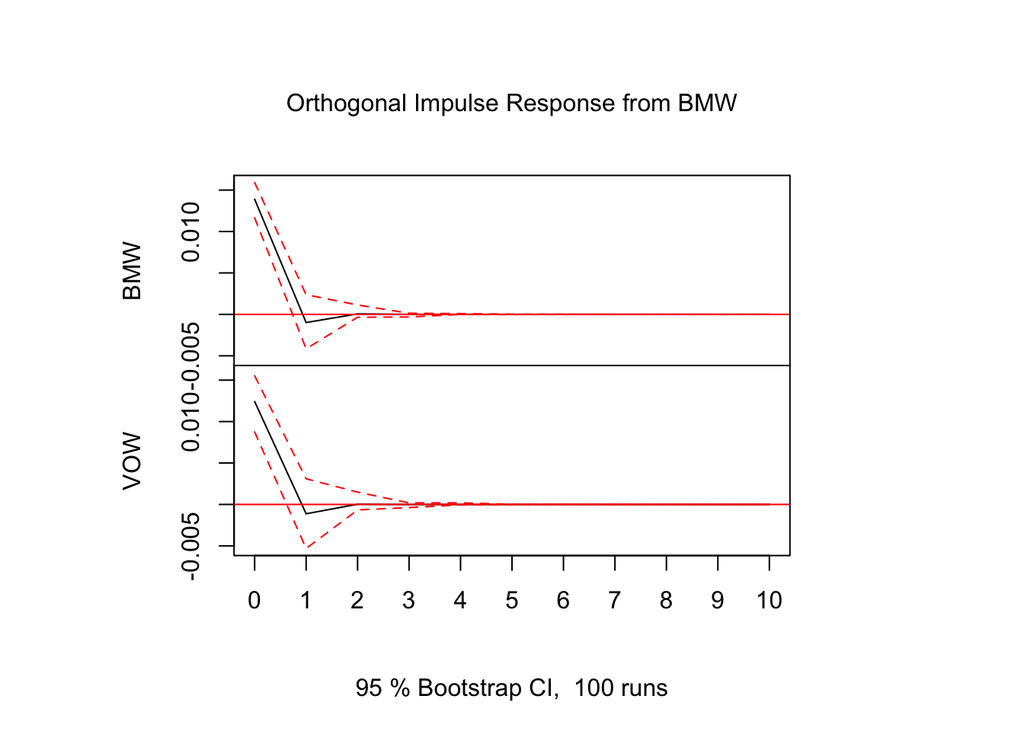

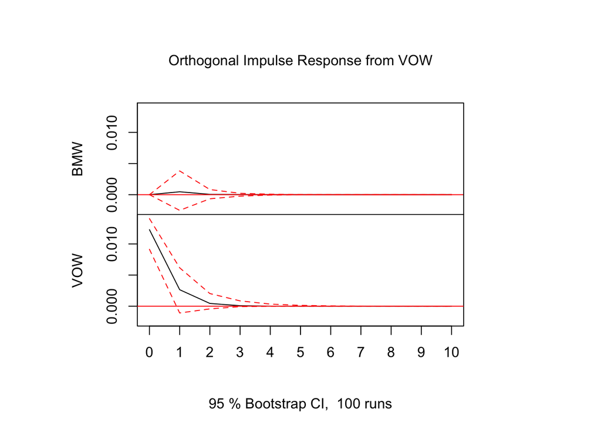

## Prediccion del modelo

```r
##prediccion
predict(model.var, n.ahead = 8, ci = 0.95)
```

```
## $BMW
##              fcst       lower      upper         CI
## [1,] -0.002426834 -0.02966458 0.02481092 0.02723775
## [2,] -0.002171234 -0.02949261 0.02515014 0.02732138
## [3,] -0.002229318 -0.02955114 0.02509251 0.02732182
## [4,] -0.002232639 -0.02955447 0.02508920 0.02732183
## [5,] -0.002233718 -0.02955555 0.02508812 0.02732183
## [6,] -0.002233878 -0.02955571 0.02508796 0.02732183
## [7,] -0.002233909 -0.02955574 0.02508793 0.02732183
## [8,] -0.002233915 -0.02955575 0.02508792 0.02732183
##
## $VOW
##              fcst       lower      upper         CI
## [1,] -0.001633452 -0.03587292 0.03260601 0.03423947
## [2,] -0.002461232 -0.03716303 0.03224057 0.03470180
## [3,] -0.002709804 -0.03742258 0.03200297 0.03471278
## [4,] -0.002747523 -0.03746068 0.03196563 0.03471315
## [5,] -0.002754751 -0.03746792 0.03195841 0.03471316
## [6,] -0.002756015 -0.03746918 0.03195715 0.03471317
## [7,] -0.002756244 -0.03746941 0.03195692 0.03471317
## [8,] -0.002756285 -0.03746945 0.03195688 0.03471317
```